# GLMs for Car Insurance Pricing: Model Assessment

Mick Cooney mickcooney@gmail.com

13 July 2016

This document is part of a series investigating the use of generalised linear models to price car insurance. This document assesses the pricing models built previously and uses MonteCarlo simulation to discover the range of possible outcomes that are possible assuming we get the data correct. The main focus is to get assess the distribution of possible outcomes.

# 1 Set Parameters and Load Data

Before we begin we configure some parameters needed for the simulations.

```r
set.seed(242)

n_sim <- 500

largeloss_threshold <- 5000
largeloss_sf        <- 2.72
largeloss_rate      <- 0.001588
```

We load the various datasets, the model fits and the price calculation.

```r
policy_dt <- read_feather("data/policy_data.feather")
claim_dt  <- read_feather("data/claim_data.feather")

trainpolicy_dt <- read_feather("data/train_data.feather")
validpolicy_dt <- read_feather("data/valid_data.feather")
testpolicy_dt  <- read_feather("data/test_data.feather")


setDT(trainpolicy_dt)
setDT(validpolicy_dt)
setDT(testpolicy_dt)

glimpse(trainpolicy_dt)
```

```
## Observations: 245,068
## Variables: 19
## $ policy_id      <fct> 1, 2, 4, 5, 6, 8, 10, 13, 15, 16, 21, 24, 25, 26, 27, 29, 30, ...
## $ claim_count    <int> 0, 0, 0, 0, 0, 0, 0, 0, 0, 0, 0, 0, 0, 0, 0, 0, 0, 0, 0, 0, 0,...
## $ exposure       <dbl> 0.09, 0.84, 0.45, 0.15, 0.75, 0.05, 0.34, 0.55, 0.01, 0.87, 0....
## $ power          <fct> g, g, f, g, g, d, i, e, e, e, h, j, e, i, i, e, f, f, f, f, e,...
## $ car_age        <int> 0, 0, 2, 0, 0, 0, 0, 0, 0, 0, 0, 8, 0, 4, 4, 0, 0, 0, 0, 0, 8,...
## $ driver_age     <int> 46, 46, 38, 41, 41, 27, 44, 33, 33, 54, 50, 30, 73, 40, 40, 45...
## $ brand          <fct> Japanese (except Nissan) or Korean, Japanese (except Nissan) o...
## $ fuel           <fct> Diesel, Diesel, Regular, Diesel, Diesel, Regular, Regular, Reg...
## $ region         <fct> Aquitaine, Aquitaine, Nord-Pas-de-Calais, Pays-de-la-Loire, Pa...
## $ density        <int> 76, 76, 3003, 60, 60, 695, 27000, 1746, 1746, 781, 3545, 3661,...
## $ total_claims   <dbl> 0, 0, 0, 0, 0, 0, 0, 0, 0, 0, 0, 0, 0, 0, 0, 0, 0, 0, 0, 0, 0,...
## $ cat_driver_age <chr> "(42,74]", "(42,74]", "(26,42]", "(26,42]", "(26,42]", "(26,42...
## $ cat_car_age    <chr> "[0,1]", "[0,1]", "(1,4]", "[0,1]", "[0,1]", "[0,1]", "[0,1]",...
## $ cat_density    <chr> "(40,200]", "(40,200]", "(500,4.5e+03]", "(40,200]", "(40,200]...
## $ agg_power      <chr> "4", "4", "3", "4", "4", "1", "other", "2", "2", "2", "5", "7"...
## $ agg_power_2    <chr> "4", "4", "3", "4", "4", "1", "6", "2", "2", "2", "5", "7", "2...
## $ agg_region     <int> 1, 1, 8, 9, 9, 1, 6, 6, 6, 8, 6, 6, 8, 6, 6, 10, 6, 6, 6, 3, 6...
## $ price_quote    <dbl> 8.658521, 80.812867, 48.847051, 13.992998, 69.964989, 5.095379...
## $ risk_premium   <dbl> 6.413720, 59.861383, 36.183001, 10.365184, 51.825918, 3.774355...
```

```r
glimpse(validpolicy_dt)
```

```
## Observations: 50,000
## Variables: 19
## $ policy_id      <fct> 298518, 407526, 181361, 384084, 341700, 243582, 116344, 64291,...
## $ claim_count    <int> 0, 0, 0, 0, 0, 0, 0, 0, 0, 0, 0, 0, 0, 0, 0, 0, 0, 0, 0, 0, 0,...
## $ exposure       <dbl> 0.08, 0.38, 0.06, 0.26, 0.95, 0.24, 1.00, 0.93, 0.82, 0.04, 1....
## $ power          <fct> f, g, f, f, f, e, g, f, g, j, k, f, f, g, g, h, d, f, e, g, h,...
## $ car_age        <int> 17, 1, 11, 1, 5, 3, 10, 0, 6, 4, 6, 12, 2, 0, 1, 5, 0, 3, 4, 1...
## $ driver_age     <int> 29, 63, 29, 58, 26, 58, 41, 63, 48, 46, 66, 73, 33, 40, 30, 53...
## $ brand          <fct> Renault, Nissan or Citroen, Japanese (except Nissan) or Korean...
## $ fuel           <fct> Regular, Diesel, Diesel, Regular, Diesel, Regular, Diesel, Die...
## $ region         <fct> Poitou-Charentes, Nord-Pas-de-Calais, Aquitaine, Ile-de-France...
## $ density        <int> 632, 2648, 280, 15703, 55, 158, 97, 146, 522, 2790, 18, 44, 10...
## $ total_claims   <dbl> 0, 0, 0, 0, 0, 0, 0, 0, 0, 0, 0, 0, 0, 0, 0, 0, 0, 0, 0, 0, 0,...
## $ cat_driver_age <chr> "(26,42]", "(42,74]", "(26,42]", "(42,74]", "(22,26]", "(42,74...
## $ cat_car_age    <chr> "(15,Inf]", "[0,1]", "(4,15]", "[0,1]", "(4,15]", "(1,4]", "(4...
## $ cat_density    <chr> "(500,4.5e+03]", "(500,4.5e+03]", "(200,500]", "(4.5e+03,Inf]"...
## $ agg_power      <chr> "3", "4", "3", "3", "3", "2", "4", "3", "4", "7", "other", "3"...
## $ agg_power_2    <chr> "3", "4", "3", "3", "3", "2", "4", "3", "4", "7", "other", "3"...
## $ agg_region     <int> 10, 8, 1, 6, 3, 3, 9, 2, 9, 6, 4, 4, 4, 4, 2, 4, 8, 1, 4, 4, 3...
## $ price_quote    <dbl> 7.270329, 49.734061, 6.940086, 30.790705, 151.944285, 19.28092...
## $ risk_premium   <dbl> 5.385429, 36.840045, 5.140804, 22.807930, 112.551322, 14.28216...
```

```r
glimpse(testpolicy_dt)
```

```
## Observations: 100,000
## Variables: 17
## $ policy_id      <fct> 322599, 2598, 139106, 280941, 271277, 317005, 309560, 384459, ...
## $ claim_count    <int> 0, 0, 0, 0, 0, 0, 0, 0, 0, 0, 0, 1, 0, 0, 0, 0, 0, 0, 0, 0, 0,...
## $ exposure       <dbl> 1.00, 0.53, 0.04, 0.28, 0.11, 0.26, 0.12, 0.64, 0.87, 0.42, 0....
## $ power          <fct> e, e, d, f, h, d, h, d, e, d, e, e, d, e, e, g, j, g, e, g, d,...
## $ car_age        <int> 3, 1, 3, 6, 1, 4, 8, 15, 4, 18, 6, 6, 13, 4, 5, 5, 4, 4, 6, 14...
## $ driver_age     <int> 71, 52, 50, 45, 56, 26, 31, 41, 54, 26, 38, 41, 37, 33, 46, 51...
## $ brand          <fct> Volkswagen, Audi, Skoda or Seat, Opel, General Motors or Ford,...
## $ fuel           <fct> Regular, Diesel, Regular, Diesel, Diesel, Regular, Regular, Re...
## $ region         <fct> Bretagne, Centre, Aquitaine, Centre, Nord-Pas-de-Calais, Ile-d...
## $ density        <int> 473, 1313, 280, 1313, 4024, 2007, 2498, 2642, 68, 153, 4327, 4...
## $ total_claims   <dbl> 0, 0, 0, 0, 0, 0, 0, 0, 0, 0, 0, 1755, 0, 0, 0, 0, 0, 0, 0, 0,...
## $ cat_driver_age <chr> "(42,74]", "(42,74]", "(42,74]", "(42,74]", "(42,74]", "(22,26...
## $ cat_car_age    <chr> "(1,4]", "[0,1]", "(1,4]", "(4,15]", "[0,1]", "(1,4]", "(4,15]...
## $ cat_density    <chr> "(200,500]", "(500,4.5e+03]", "(200,500]", "(500,4.5e+03]", "(...
## $ agg_power      <chr> "2", "2", "1", "3", "5", "1", "5", "1", "2", "1", "2", "2", "1...
## $ agg_power_2    <chr> "2", "2", "1", "3", "5", "1", "5", "1", "2", "1", "2", "2", "1...
## $ agg_region     <int> 3, 4, 1, 4, 8, 6, 1, 8, 10, 3, 6, 4, 4, 1, 4, 6, 5, 6, 6, 4, 5...
```

```r
claimrate_model_glm <- readRDS("data/claim_model.rds")
claimsize_model_glm <- readRDS("data/size_model.rds")

premium_quoter <- readRDS("data/premium_quoter.rds")
```

In this document we focus assessing our pricing model. No model is perfect, and it is important to understand how a pricing model may fail and what risks are posed.

To start with, we make a very strong and generous assumption: we assume our pricing model is correct and the risks assumed by the business are represented correctly by the models.

This assumption is absurd, we already know the model has flaws, and spent part of the last document working on them. That said, it makes for a easy and frictionless starting point, and should help illustrate the extent of tail risk we have in the model.

# 2 Evaluating the Model with Same Parameters

The idea is to use the same parameters used to price the policies to simulate claim data. For each simulation iteration and policy, we perform a number of steps:

- Use the Poisson model to estimate claim counts for the policy
- Use the Gamma model to estimate the size of the claims
- Use the large loss claim frequency to estimate the count of large claims
- Use the power law calculation to simulate the size of the large claims

Note that for performance reasons the logical steps outlined above may be implemented differently without changing the outcome of the simulation overall.

Having done the above for every policy and claim, we run multiple MonteCarlo simulations to estimate the distribution of possible outcomes *conditional on the model being correct*.

This approach may seem pointless - using a model to validate itself - but it is not. It gives us a sense of the best case scenario from a probabilistic perspective.

## 2.1 Converting GLM Output to Distribution Parameters

To calculate simulations we require, we need to convert the output of GLM regressions to parameters for the underlying distributions. GLMs fit the data to produce the mean and dispersion of the data - perfect for the use of a normal distribution as it is parameterised by the mean and variance - but other distributions use different parameters.

The Poisson distribution has a single parameter, the mean, so we can use that output directly if we wish to simulate from a Poisson.

The Gamma distribution has a few choices for parameterisation, the most common of which is to use the shape, $k$ and the rate, $\beta$. The shape is the reciprocal of the dispersion in the dataset, and the rate is given by

$$\beta = \frac{k}{\mu}.$$

With these transformations we can use the model fits to produce data in our simulations.

## 2.2 Assessing the Model with Training Data

```r
simulator_creator <- create_assessment_simulator(claimrate_model_glm
                                                ,claimsize_model_glm
                                                ,largeloss_threshold
                                                ,largeloss_rate
                                                ,largeloss_sf)
```

With this infrastructure in place we are now in position to assess the model using the training dataset.

For each MonteCarlo iteration we simulate a claim count for each policy based on the Poisson model we fit (we exclude large claims for now). For each policy with at least one claim, we sample a claim amount using the gamma distribution.

With the ‘usual’ losses simulated, we then sample a total number of larger claims using a Poisson distribution with the large claim rate and then use that as the number of samples we draw from the power law distribution. The sum of these two claim amounts are the total claims on the book for that iteration.

We perform the above simulation for a large number of simulations.

```r
use_dt <- trainpolicy_dt

run_mc_train_sim <- simulator_creator(use_dt)

sim_train_losses <- replicate(n_sim, run_mc_train_sim())

total_riskprem   <- sum(use_dt$risk_premium)
received_premium <- sum(use_dt$price_quote)
```

Having ran the simulations we now plot the distribution of the simulated claim payments against the premium received.

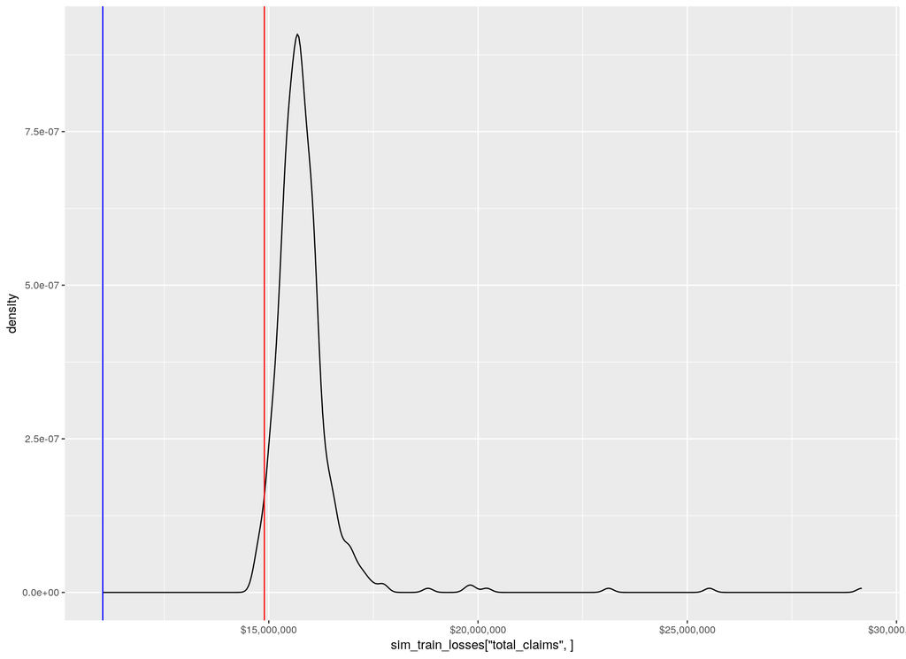

```r
ggplot() +
    stat_density(aes(x = sim_train_losses['total_claims',]), geom = 'line') +
    geom_vline(aes(xintercept = received_premium), colour = 'red') +
    geom_vline(aes(xintercept = total_riskprem),   colour = 'blue') +
    scale_x_continuous(labels = scales::dollar)
```

This looks poor, much worse than we would anticipate given that we are reusing the parameters in the simulation. The risk premium receive is way below the amount of claims paid out. Even the total premium received - which should cover the additional costs of running the business and profit margin - do not cover the losses. Why do the outputs look so bad?

Is it possible that using the expectation for the Gamma distribution for the pricing is not a good idea due to the tail? We can check this by suppressing the simulation of the claim amount and instead using a fixed amount for each claim and seeing how this looks.

```r
run_mc_train_fixedclaim_sim <- simulator_creator(use_dt
                                                ,simulate_claim_size = FALSE)

sim_train_fixedclaim_losses <- replicate(n_sim, run_mc_train_fixedclaim_sim())

total_riskprem   <- sum(use_dt$risk_premium)
received_premium <- sum(use_dt$price_quote)
```

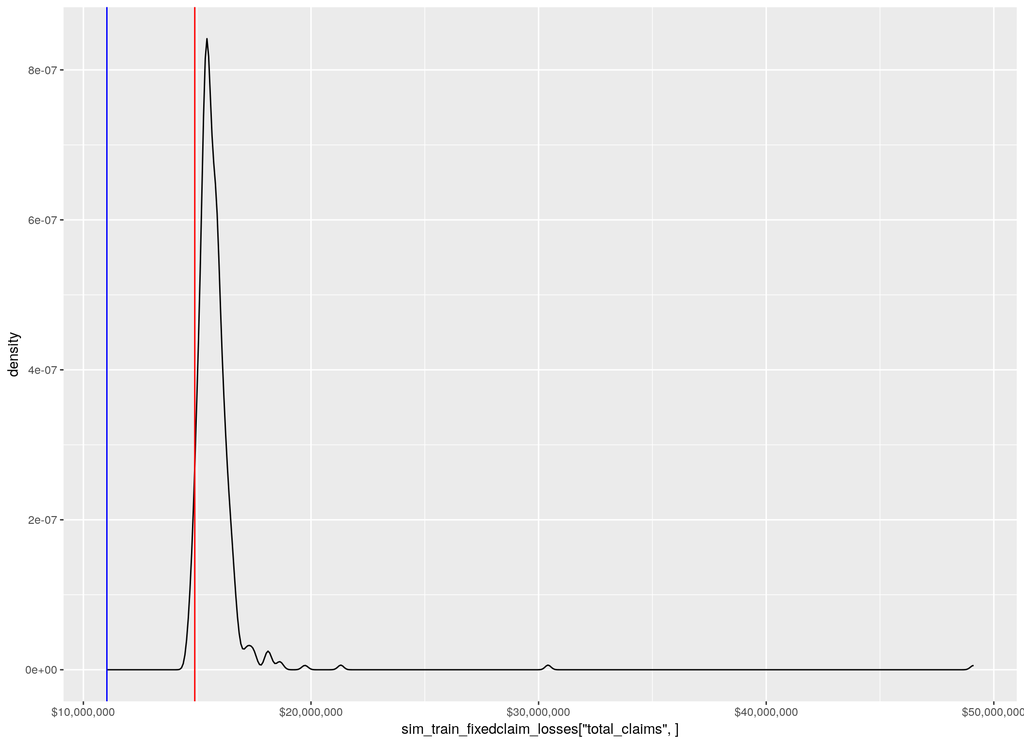

```r
ggplot() +
    stat_density(aes(x = sim_train_fixedclaim_losses['total_claims',]), geom = 'line') +
    geom_vline(aes(xintercept = received_premium), colour = 'red') +
    geom_vline(aes(xintercept = total_riskprem),   colour = 'blue') +
    scale_x_continuous(labels = scales::dollar)
```

```r
use_dt <- validpolicy_dt

run_mc_valid_sim <- simulator_creator(use_dt)

sim_valid_losses <- replicate(n_sim, run_mc_valid_sim())

total_riskprem   <- sum(use_dt$risk_premium)
received_premium <- sum(use_dt$price_quote)
```

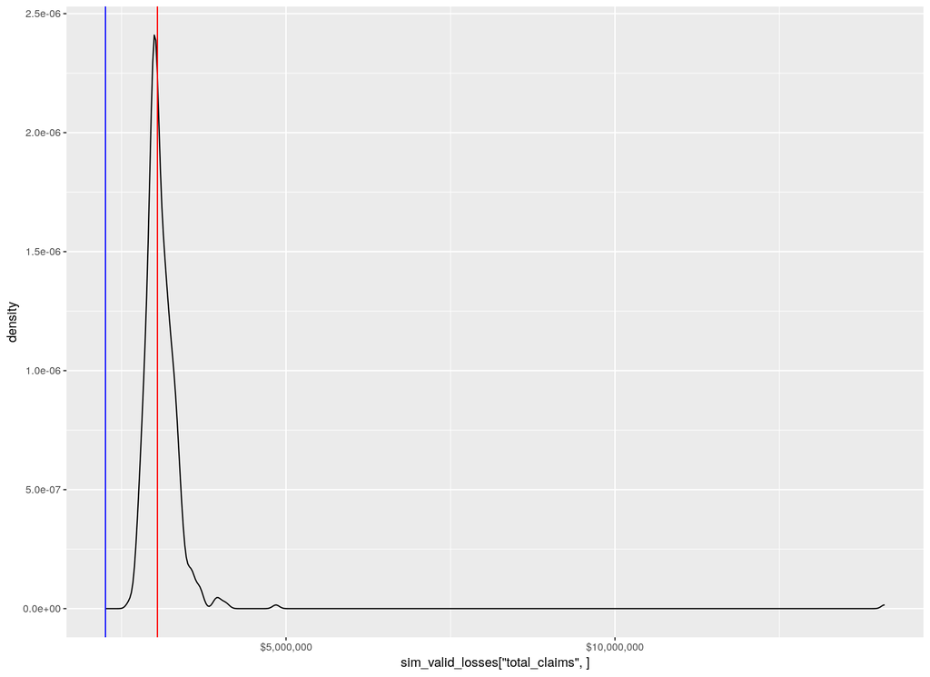

```r
ggplot() +
    stat_density(aes(x = sim_valid_losses['total_claims',]), geom = 'line') +
    geom_vline(aes(xintercept = received_premium), colour = 'red') +
    geom_vline(aes(xintercept = total_riskprem),   colour = 'blue') +
    scale_x_continuous(labels = scales::dollar)
```